# Planning Public Policy in Argentina

## 7. Cluster using K means

```r
# Set seed to 1234 for reproducibility
set.seed(1234)

head(argentina_pca$ind$coord)
```

```
##        Dim.1       Dim.2       Dim.3      Dim.4       Dim.5
## 1 -2.3614699  5.85722972  0.02887238  1.1415873 -0.55664309
## 2 -0.6584545 -0.48651253 -1.29107656 -0.2415875 -0.03742897
## 3 -2.5752814  0.52381577  1.70307390 -0.9930687  2.11197740
## 4  2.8268547  0.15875925  0.48894162 -1.0256780  0.09720908
## 5  4.3000823  0.09073316  0.08145973  0.8101764  1.08427385
## 6 -2.7072455 -1.36535411 -0.23583031  0.9771357 -0.60816245
```

```r
# Create an intermediate data frame with pca_1 and pca_2
argentina_comps <- tibble(pca_1 = argentina_pca$ind$coord[, 1],
                          pca_2 = argentina_pca$ind$coord[, 2])

# Cluster the observations using the first 2 components and print its contents
( argentina_km <- kmeans(argentina_comps, centers = 4, nstart = 20, iter.max = 50) )
```

```
## K-means clustering with 4 clusters of sizes 6, 1, 8, 7
##
## Cluster means:
##        pca_1      pca_2
## 1  3.1637648  0.1200775
## 2 -2.3614699  5.8572297
## 3 -0.1320515 -0.3199319
## 4 -2.2235295 -0.5740342
##
## Clustering vector:
##  [1] 2 3 4 1 1 4 3 1 3 4 3 4 1 4 3 1 3 3 4 4 1 3
##
## Within cluster sum of squares by cluster:
## [1] 4.375350 0.000000 3.109136 8.403846
##  (between_SS / total_SS =  89.7 %)
##
## Available components:
##
## [1] "cluster"      "centers"      "totss"        "withinss"
## [5] "tot.withinss" "betweenss"    "size"         "iter"
## [9] "ifault"
```

## 8. Components with colors

Now that we have cluster assignments for each province, we will plot the provinces according to their principal components coordinates, colored by the cluster.

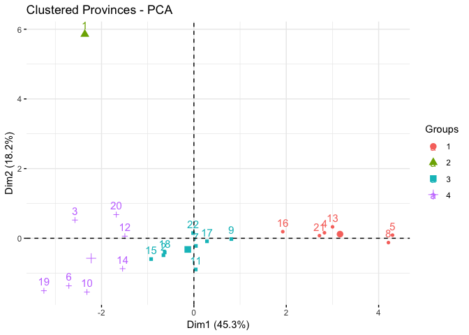

```r
# Convert assigned clusters to factor
clusters_as_factor <- factor(argentina_km$cluster)

# Plot individulas colored by cluster
fviz_pca_ind(argentina_pca,
             title = "Clustered Provinces - PCA",
             habillage = clusters_as_factor)
```

## 9. Buenos Aires, in a league of its own

We will focus on exploring clusters 1, 2, and 3 in terms of the original variables in the next few tasks.

Since the vectors corresponding to `gdp` and `pop` are in the same direction as Dimension 2, Buenos Aires has high GDP and high population. Let’s visualize this pattern with a plot of `gdp` against `cluster` (we should get similar results with `pop`).

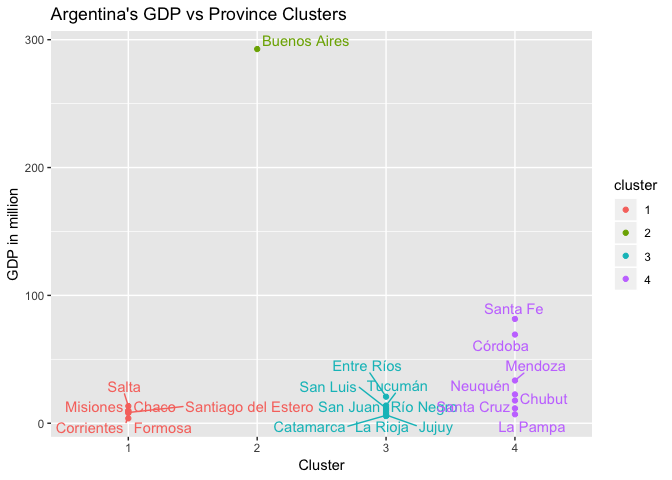

```r
library(ggrepel)

# Add cluster column to argentina
argentina <- argentina %>%
               mutate(cluster= clusters_as_factor)

# Make a scatterplot of gdp vs. cluster, colored by cluster
ggplot(argentina, aes(y = gdp/1000000, x = cluster, color = cluster)) +
  geom_point() +
  geom_text_repel(aes(label = province), show.legend = FALSE) +
  labs(x = "Cluster", y = "GDP in million") +
  ggtitle("Argentina's GDP vs Province Clusters")
```

## 10. The rich provinces

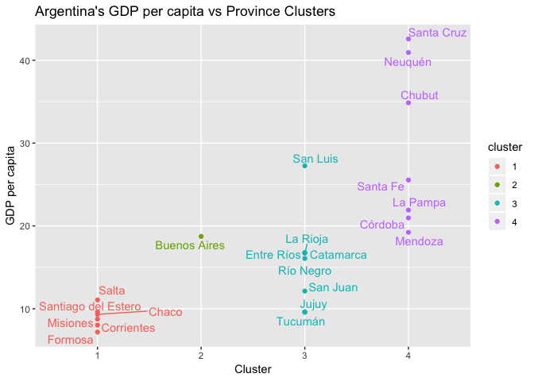

```r
# Make a scatterplot of GDP per capita vs. cluster, colored by cluster
ggplot(argentina, aes(y = gdp_per_cap, x = cluster, color = cluster)) +
  geom_point() +
  geom_text_repel(aes(label = province), show.legend = FALSE) +
  labs(x = "Cluster", y = "GDP per capita") +
  ggtitle("Argentina's GDP per capita vs Province Clusters")
```

## 11. The poor provinces

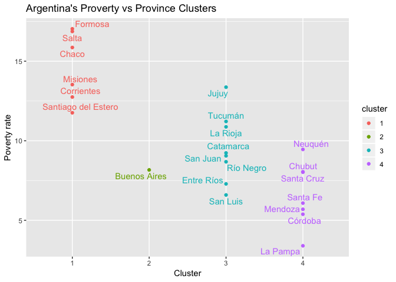

```r
# Make scatterplot of poverty vs. cluster, colored by cluster
ggplot(argentina, aes(x = cluster, y = poverty, color = cluster)) +
  geom_point() +
  labs(x = "Cluster", y = "Poverty rate") +
  geom_text_repel(aes(label = province), show.legend = FALSE) +
  ggtitle("Argentina's Proverty vs Province Clusters")
```

## 12. Planning for public policy

Now that we have an idea of how social and economic welfare varies among provinces, we’ve been asked to help plan an education program. A pilot phase of the program will be carried out to identify design issues. Our goal is to select the proposal with the most diverse set of provinces:

1. Tucumán, San Juán, and Entre Ríos
2. Córdoba, Santa Fé, and Mendoza
3. Buenos Aires, Santa Cruz, and Misiones

Which proposal includes the most diverse set of provinces?

```r
# Assign pilot provinces to the most diverse group
pilot_provinces <- 3
```